# San Antonio 2021 City Compensation Data Analysis

### By: Dan Schumacher

### Here is a look at the data we are playing with

```python
comp.head(5)
```

|  | first_name | middle_name | last_name | employee_category | hire_date | base_pay | leave_payout | other_pay | overtime | gross_earnings | ... | ethnic_orgin | employee_subgroup | withdraw_date | annual_salary | additional_benefits | business_area | BA_tags | years_service | full_name | ethnicity_tags |
| --- | --- | --- | --- | --- | --- | --- | --- | --- | --- | --- | --- | --- | --- | --- | --- | --- | --- | --- | --- | --- | --- |
| 0 | ERIK | J | WALSH | CIVILIAN | 1994-06-06 | 312,000.00 | 12,000.00 | 27,785.73 | 0.00 | 351,785.73 | ... | HISPANIC OR LATINO | 2A CITY MGR FT | NaT | 312,000.00 | 92,976.08 | CITY MANAGER | MAN | 25.62 | ERIK J WALSH | Hisp/Lat |
| 1 | ANDREW | NaN | SEGOVIA | CIVILIAN | 2016-08-29 | 299,625.82 | 19,446.75 | 6,396.56 | 0.00 | 325,469.13 | ... | HISPANIC OR LATINO | 2B DEPT DIR FT | NaT | 299,625.82 | 66,253.57 | CITY ATTORNEY | ATT | 3.39 | ANDREW SEGOVIA | Hisp/Lat |
| 2 | SCOTT | VINCENT | BELL | UNIFORM | 1988-09-26 | 88,889.24 | 177,027.50 | 31,446.46 | 4,004.35 | 301,367.55 | ... | WHITE (NON HISPANIC OR LATINO) | UNIFORM WITHDRAWN | 2021-08-20 | 104,664.04 | 59,119.18 | POLICE | POL | 31.32 | SCOTT VINCENT BELL | White |
| 3 | TROY | RAY | TORRES | UNIFORM | 1992-10-12 | 98,047.62 | 171,780.52 | 22,970.99 | 0.00 | 292,799.13 | ... | HISPANIC OR LATINO | UNIFORM WITHDRAWN | 2021-08-20 | 117,744.12 | 59,070.37 | POLICE | POL | 27.27 | TROY RAY TORRES | Hisp/Lat |
| 4 | MARK | STEVEN | TREVINO | UNIFORM | 1993-11-27 | 94,099.41 | 5,267.07 | 29,166.55 | 147,909.38 | 276,442.41 | ... | HISPANIC OR LATINO | 5A FIRE FULL-TIME | NaT | 96,830.76 | 64,258.76 | FIRE | FIR | 26.15 | MARK STEVEN TREVINO | Hisp/Lat |

5 rows × 23 columns

### How much does the city spend on total total-compensation?

```python
ba_vs_tc = comp.groupby(by='business_area')['total_compensation'].sum().sort_values(ascending=False)

print('Total COSA spending on compensation: ' f'{ba_vs_tc.sum():,.0f}')
```

```
Total COSA spending on compensation: 1,206,680,843
```

### How many employees are in each business area?

There are 39 Business areas. They have the following number of employees

```python
num_employees
```

```
POLICE                                  3566
FIRE                                    1923
PARKS & RECREATION                      1198
PUBLIC WORKS                             808
SOLID WASTE MANAGEMENT                   792
LIBRARY                                  520
HEALTH                                   511
AVIATION                                 465
DEVELOPMENT SERVICES                     464
PRE K 4 SA                               463
HUMAN SERVICES                           390
INFORMATION TECHNOLOGY SVCS              324
CONVENTION & SPORTS FACILITIES           315
HUMAN RESOURCES                          304
BUILDING & EQUIPMENT SERVICES            192
MUNICIPAL COURTS                         173
ANIMAL CARE SERVICES                     156
FINANCE                                  148
CENTER CITY DEVELOPMENT & OPERATIONS     141
CITY ATTORNEY                             86
NEIGHBORHOOD & HOUSING SVCS               75
311                                       75
GOVERNMENT & PUBLIC AFFAIRS               39
ECONOMIC DEVELOPMENT                      37
CITY CLERK                                30
CITY AUDITOR                              27
RISK MANAGEMENT                           27
PLANNING                                  23
MAYOR & COUNCIL                           21
ARTS & CULTURE                            20
CITY MANAGER                              20
MANAGEMENT & BUDGET                       18
HISTORIC PRESERVATION                     18
TRANSPORTATION                            12
INNOVATION                                10
SUSTAINABILITY                            10
WORLD HERITAGE                             7
READY TO WORK                              6
EQUITY                                     5
Name: business_area, dtype: int64
```

### Here is a graph!

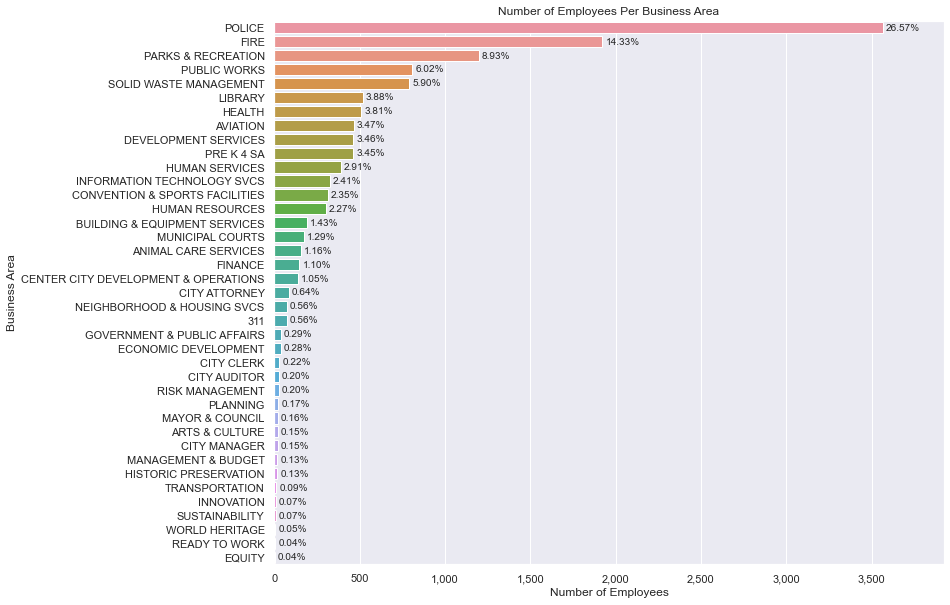

```python
#set up and size the figure
plt.figure(figsize=(12,10))

#plot
ax = sns.barplot(y=num_employees.index, x= num_employees.values)

#set titles and labels
labels = ax.set(xlabel='Number of Employees', ylabel='Business Area', title='Number of Employees Per Business Area')

#add the percentage labels
annotations = ax.bar_label(ax.containers[0],labels=['%.2f%%' % n for n in percent_employment], padding=3)
ax.margins(x=0.1)

#give thousand seperator to x axis
ax.xaxis.set_major_formatter(mpl.ticker.StrMethodFormatter('{x:,.0f}'))

#save the graph if you want to
if record:
    plt.savefig('1.3_Number of Employees Per Business Area.png')
```

```python
lower_half = percent_employment[:20:-1].sum()

print(f'The bottom 20 of the 39 business areas only got {"{0:,.2f}".format(lower_half)}% of the city spending on employee compensation')
```

[output not shown]

### What business area spends the most on salaries?

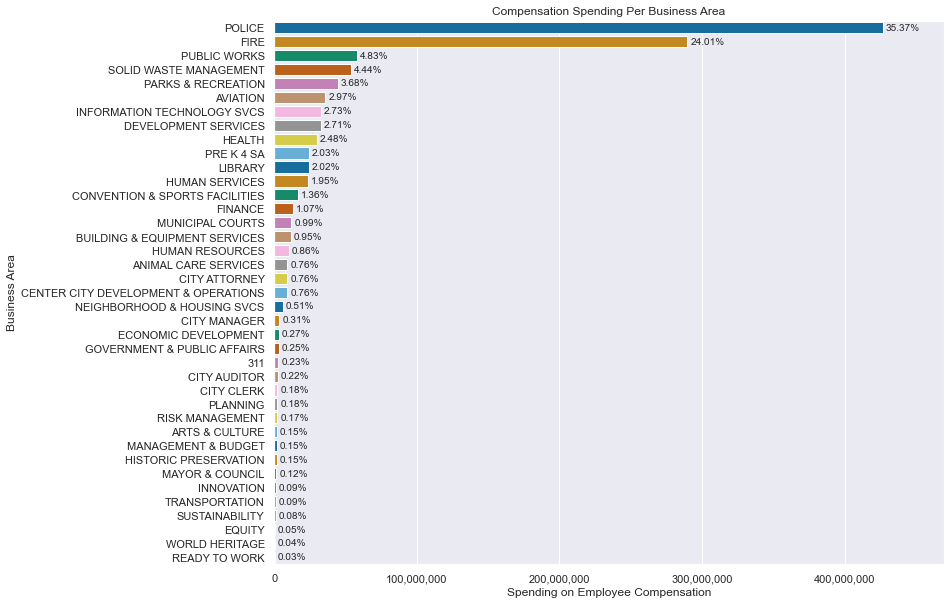

```python
#set up and size the figure
plt.figure(figsize=(12,10))

#plot
palette = sns.color_palette("colorblind")
ax = sns.barplot(y=ba_vs_tc.index, x=ba_vs_tc.values,palette=palette)

#set titles and labels
labels = ax.set(xlabel='Spending on Employee Compensation', ylabel='Business Area', title='Compensation Spending Per Business Area')

#add the percentage labels
annotations = ax.bar_label(ax.containers[0],labels=['%.2f%%' % n for n in percent_compensation], padding=3)
ax.margins(x=0.1)

#give thousand seperator to x axis
ax.xaxis.set_major_formatter(mpl.ticker.StrMethodFormatter('{x:,.0f}'))

#save the graph if you want to
if record:
    plt.savefig('1.4_Total Employee Compensation by Business Area.png')
```

Despite police and fire making 41% of the employees, they take 60% of the compensation

### Percent of city employment vs percent of city compensation

Business areas on top of the red line have a higher percentage of compensation compared to employees

Business areas on bottom of the red line have a higher percentage of employees compared to compensation

Notice that parks an rec takes up almost 10% of the employment but less than 5% of the total compensation

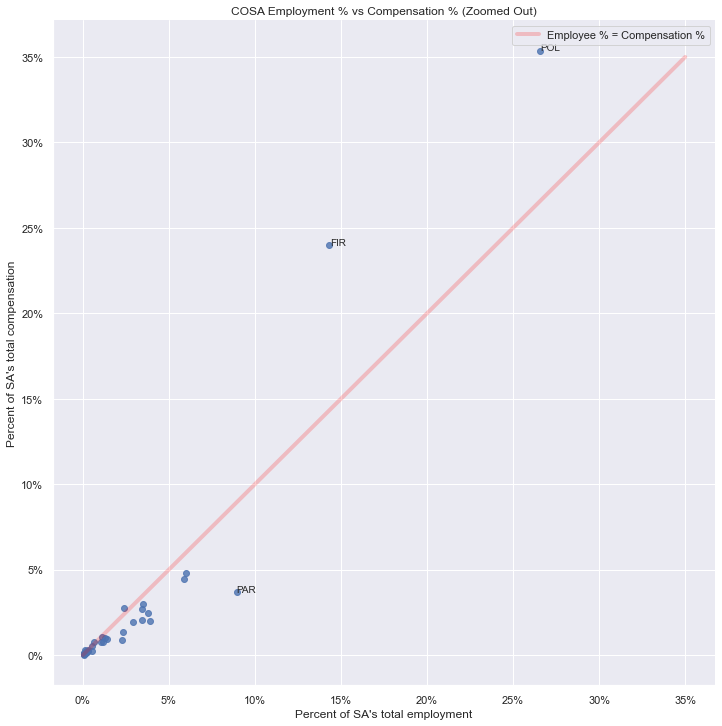

```python
#make a scatterplot
ax = sns.lmplot(x='p_of_total_employment', # Horizontal axis
           y='p_of_total_compensation', # Vertical axis
           data=comparepercentages, # Data source
           fit_reg=False, # don't fit regression line (we will do this later as red)
           height = 10, # size and dimension
           aspect =1)

#Make a y=x line that's red
ax =sns.lineplot(x=list(range(0,36)),
            y=list(range(0,36)),
                 color='red',
                alpha=.2,
                lw=4,
                 label='Employee % = Compensation %')
plt.legend()

#give percent sign seperator to x and y axis
ax.xaxis.set_major_formatter(mpl.ticker.StrMethodFormatter('{x:,.0f}%'))
ax.yaxis.set_major_formatter(mpl.ticker.StrMethodFormatter('{x:,.0f}%'))

#Set title
plt.title('COSA Employment % vs Compensation % (Zoomed Out)')
# Set x-axis label
plt.xlabel("Percent of SA's total employment")
# Set y-axis label
plt.ylabel("Percent of SA's total compensation")

#show BA tags
label_point(x=show_tags.p_of_total_employment,
            y=show_tags.p_of_total_compensation,
            val=show_tags.BA_tags,
            ax=plt.gca())

plt.show()
```

Let's zoom in on those lower clusters

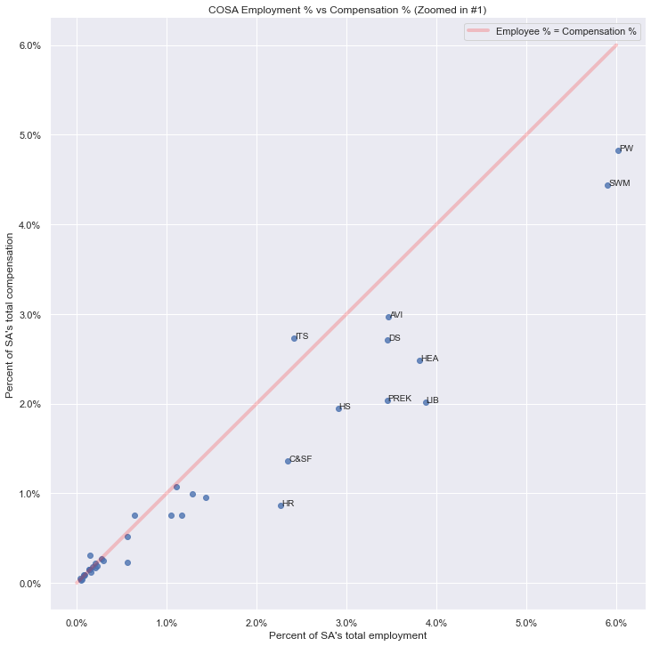

```python
# Zoom #1
ax = sns.lmplot(x='p_of_total_employment', # Horizontal axis
           y='p_of_total_compensation', # Vertical axis
           data=cpdropped, # Data source
           fit_reg=False, # Don't fix a regression line
           height = 10,
           aspect = 1 ) # size and dimension

#Make a regression line that's red
ax =sns.lineplot(x=list(range(0,7)),
            y=list(range(0,7)),
                 color='red',
                alpha=.2,
                lw=4,
                 label='Employee % = Compensation %')
plt.legend()

#give percent sign seperator to x and y axis
ax.xaxis.set_major_formatter(mpl.ticker.StrMethodFormatter('{x:,.1f}%'))
ax.yaxis.set_major_formatter(mpl.ticker.StrMethodFormatter('{x:,.1f}%'))


plt.title('COSA Employment % vs Compensation % (Zoomed in #1)')
# Set x-axis label
plt.xlabel("Percent of SA's total employment")
# Set y-axis label
plt.ylabel("Percent of SA's total compensation")

label_point(x=show_tags.p_of_total_employment,
            y=show_tags.p_of_total_compensation,
            val=show_tags.BA_tags,
            ax=plt.gca())
```

Even more zoom

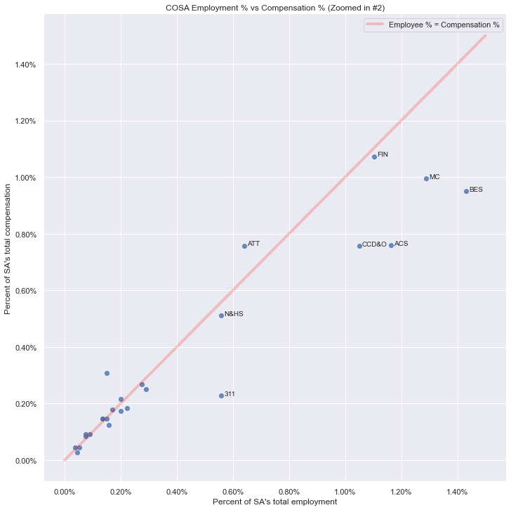

```python
ax = sns.lmplot(x='p_of_total_employment', # Horizontal axis
           y='p_of_total_compensation', # Vertical axis
           data = cpdropped, # Data source
           fit_reg=False, # Don't fix a regression line
           height = 10,
           aspect = 1 ) # size and dimension

#Make a y=x line that's red
ax = sns.lineplot(x=np.arange(0.0, 1.6, 0.1),
                  y=np.arange(0.0, 1.6, 0.1),
                  color='red',
                alpha=.2,
                lw=4,
                  label='Employee % = Compensation %')
plt.legend()

#give percent sign seperator to x and y axis
ax.xaxis.set_major_formatter(mpl.ticker.StrMethodFormatter('{x:,.2f}%'))
ax.yaxis.set_major_formatter(mpl.ticker.StrMethodFormatter('{x:,.2f}%'))

plt.title('COSA Employment % vs Compensation % (Zoomed in #2)')
# Set x-axis label
plt.xlabel("Percent of SA's total employment")
# Set y-axis label
plt.ylabel("Percent of SA's total compensation")

label_point(x=show_tags.p_of_total_employment,
            y=show_tags.p_of_total_compensation,
            val=show_tags.BA_tags,
            ax=plt.gca())
```

One last zoom in!

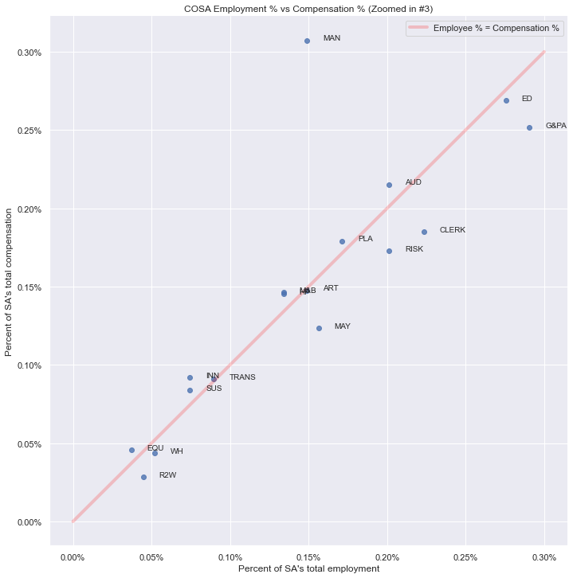

```python
ax = sns.lmplot(x='p_of_total_employment', # Horizontal axis
           y='p_of_total_compensation', # Vertical axis
           data=show_tags, # Data source
           fit_reg=False, # Don't fix a regression line
           height = 10,
           aspect = 1 ) # size and dimension

#Make a y=x line that's red
ax = sns.lineplot(x=np.arange(0.0, .4, 0.1),
                  y=np.arange(0.0, .4, 0.1),
                  color='red',
                alpha=.2,
                lw=4,label='Employee % = Compensation %')
plt.legend()

#give percent sign seperator to x and y axis
ax.xaxis.set_major_formatter(mpl.ticker.StrMethodFormatter('{x:,.2f}%'))
ax.yaxis.set_major_formatter(mpl.ticker.StrMethodFormatter('{x:,.2f}%'))

plt.title('COSA Employment % vs Compensation % (Zoomed in #3)')
# Set x-axis label
plt.xlabel("Percent of SA's total employment")
# Set y-axis label
plt.ylabel("Percent of SA's total compensation")

label_point(x=show_tags.p_of_total_employment,
            y=show_tags.p_of_total_compensation,
            val=show_tags.BA_tags,
            ax=plt.gca())
```

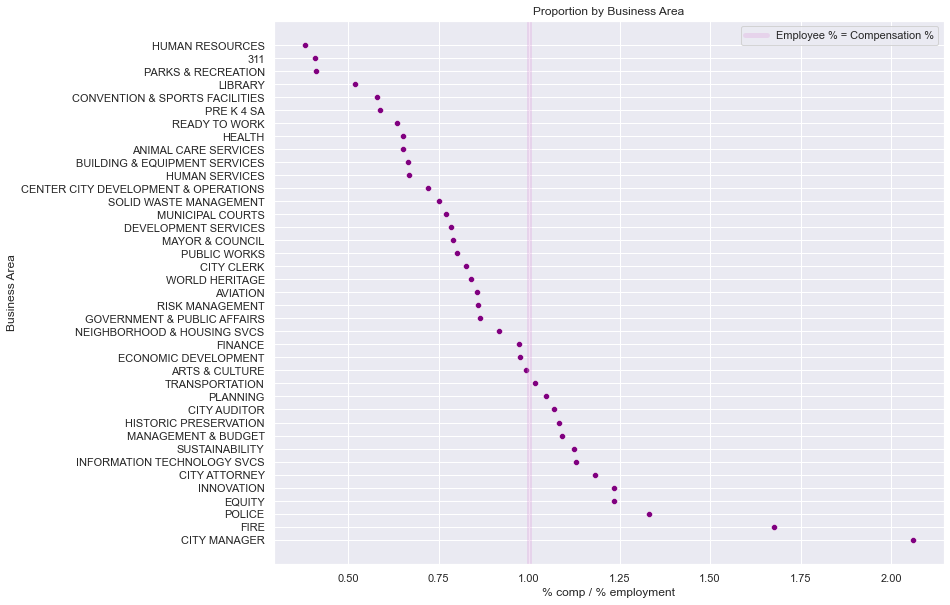

```python
plt.figure(figsize=(12,10))

ax =sns.scatterplot(data=comparepercentages.sort_values('proportion'),
             x='proportion',
             y='business_area',
                   color = 'purple')\

#create verticle line
ax.axvline(x=1,color='plum',
          lw=5,
           alpha=.3,
           label='Employee % = Compensation %')
plt.legend()

ax.set_title('Proportion by Business Area')
ax.set_xlabel('% comp / % employment')
ax.set_ylabel('Business Area')

#ax.xaxis.set_major_formatter(mpl.ticker.StrMethodFormatter('{x:,.2f}%'))
plt.show()
```

Fire and City Manager are great departments to work for as they have much more money to spend on compensation and less employees to spend the compensation on

HR, 311, Parks and Rec, and Library, have lots of employees and little compensation :(

### Part time and temp employees

The data on the previous slide could be skewed. Maybe HR, 311, Parks, etc. have the most part time/temp employees? That would pull their scores left.

```python
#make subset of data without part timers
full_time = comp[comp['employee_subgroup'] != '4C PART-TIME']

#also remove temp employees from that subset
full_time = full_time[full_time['employee_subgroup'] != '4C TEMP']

#how many full timers are there?
num_FT_emp = len(full_time)
print(f'There are {num_FT_emp} full-timer employees that work for The City of San Antonio')

#how many people did we get rid of?
num_PT_TEMPS = (len(comp) - num_FT_emp)
print(f'There are {num_PT_TEMPS} part-timers or temporary employees that work for The City of San Antonio')
```

```
There are 12692 full-timer employees that work for The City of San Antonio
There are 727 part-timers or temporary employees that work for The City of San Antonio
```

```python
FT_ba_vs_tc = full_time.groupby(by='business_area')['total_compensation'].sum().sort_values(ascending=False)

print('Total COSA spending on Full Timer compensation: ' f'{ba_vs_tc.sum():,.0f}')
```

[output not shown]

Maybe the reason HR, 311, Parks and Rec, and Library place so low is because they have a large number of part time or temporary employees. Lets just look at full timers.

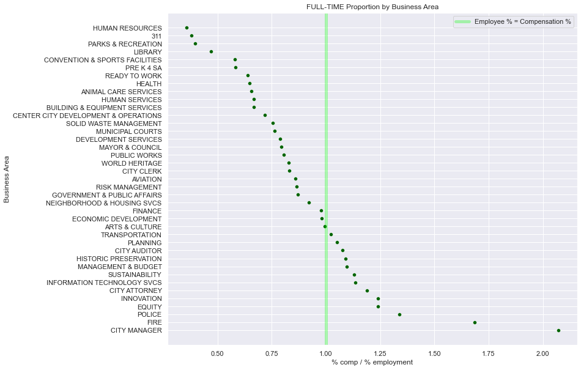

```python
plt.figure(figsize=(12,10))

ax =sns.scatterplot(data=FT_comparepercentages.sort_values('proportion'),
             x='proportion',
             y='business_area',
                   color = 'darkgreen')

#create verticle line
ax.axvline(x=1,color='lime',
           lw=5,
           alpha=.3,
          label='Employee % = Compensation %')
plt.legend()

ax.set_title('FULL-TIME Proportion by Business Area')
ax.set_xlabel('% comp / % employment')
ax.set_ylabel('Business Area')

plt.show()
```

Let's plot FT employees on top of All employees they are easier to compare

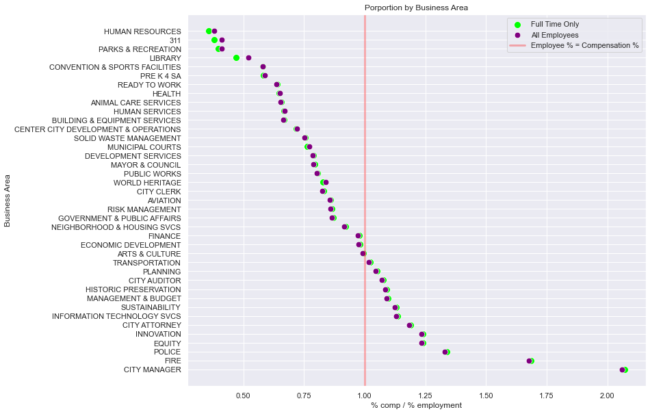

```python
#let's try plotting them at the same time

plt.figure(figsize=(12,10))

#full time scatterplot
ax1 =sns.scatterplot(data=FT_comparepercentages.sort_values('proportion'),
             x='proportion',
             y='business_area',
                   color = 'lime',
                    label='Full Time Only',
                    s=100)

#original scatterplot
ax2 =sns.scatterplot(data=comparepercentages.sort_values('proportion'),
             x='proportion',
             y='business_area',
                   color = 'purple',
                    label='All Employees',
                    s=75)

#create verticle line
ax3 = plt.axvline(x=1,
            color='red',
            lw=3,
           alpha=.3,
           label='Employee % = Compensation %')
plt.legend()

#set tiles and axes
ax1.set_title('Porportion by Business Area')
ax1.set_xlabel('% comp / % employment')
ax1.set_ylabel('Business Area')


plt.show()
```

Actually when looking at Hr, 311, Parks and Rec, and Library, full timers perform worse then the employees as a whole.

One explination would be that the partimers' compensation at is closer to the fulltimers' compensation at HR than it is at the City Manager department.

### Part time only

```python
PT_ba_vs_tc = part_timers.groupby(by='business_area')['total_compensation'].sum().sort_values(ascending=False)

print('Total COSA spending on Part Timer compensation: ' f'{PT_ba_vs_tc.sum():,.0f}$')
```

```
Total COSA spending on Part Timer compensation: 6,450,185$
```

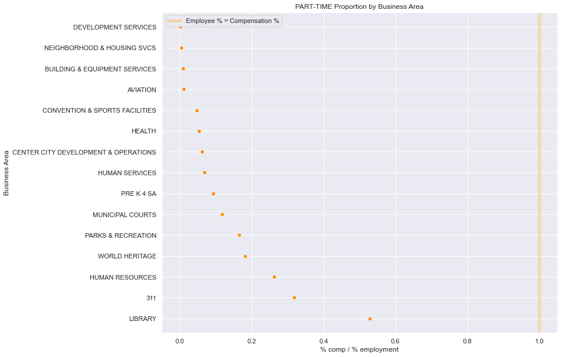

```python
plt.figure(figsize=(12,10))

ax =sns.scatterplot(data=PT_comparepercentages.sort_values('proportion'),
             x='proportion',
             y='business_area',
                   color = 'darkorange')

#create verticle line
ax.axvline(x=1,color='orange',
           lw=5,
           alpha=.3,
          label='Employee % = Compensation %')
plt.legend()

ax.set_title('PART-TIME Proportion by Business Area')
ax.set_xlabel('% comp / % employment')
ax.set_ylabel('Business Area')

plt.show()
```

This supports what I said before! Library, 311, HR, and Parks and Rec are some of the best part time jobs.

## What is the average total compensation for a city job?

```python
avg_sal = comp['total_compensation'].mean()
print("The average COSA employee's yearly total compensation is: " + f'{avg_sal:,.0f}$')
```

```
The average COSA employee's yearly total compensation is: 89,923$
```

## What is the average total compensation for a Library job?

```python
avg_lib_sal = comp[comp['business_area']=='LIBRARY']['total_compensation'].mean()
print("The average Library employee's yearly total compensation is: " + f'{avg_lib_sal:,.0f}$')
```

```
The average Library employee's yearly total compensation is: 46,772$
```

## What business area has the highest average total compensation per employee?

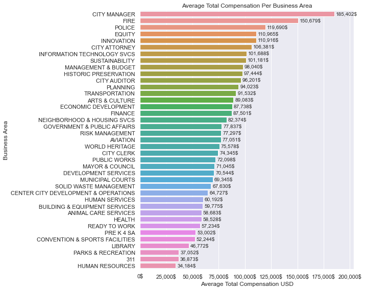

```python
#### TRYING STUFF

#set up figure
plt.figure(figsize=(10,8))



plt.ylabel('Business Area')

#plot
ax = sns.barplot(y=comp_per_empl.index, x=comp_per_empl.values)

#set title and lables
plt.title('Average Total Compensation Per Business Area')
plt.xlabel('Average Total Compensation USD')
    #make x label have thousand seperators
ax.xaxis.set_major_formatter(mpl.ticker.StrMethodFormatter('{x:,.0f}$'))

#add the percentage labels
annotations = ax.bar_label(ax.containers[0],labels=[f'{x:,.0f}$' for x in comp_per_empl], padding=3)
ax.margins(x=0.1)

#make it look nice
plt.tight_layout()

if record:
    plt.savefig('3.1_Average Annual Salary Per Business Area.png')
```

Arts and Culture and Transportation are the closest categories to the average city employee compensation

## What are the best and worst jobs by annual salary?

```python
num_jobs = comp['job_title'].nunique()

print(f'There are {num_jobs} unique job titles')
```

```
There are 847 unique job titles
```

#### Best Paying Jobs

They are all leadership roles

```python
best_jobs
```

| job_title | annual_salary |
| --- | --- |
| CITY MANAGER | $312,000 |
| CITY ATTORNEY | $299,626 |
| DEPUTY CITY MANAGER | $258,825 |
| CHIEF FINANCIAL OFFICER | $233,931 |
| POLICE CHIEF | $232,298 |
| ASSISTANT CITY MANAGER | $226,319 |
| FIRE CHIEF | $222,090 |
| CHIEF INFORMATION OFFICER | $219,587 |
| PUBLIC HEALTH DIRECTOR | $215,000 |
| FINANCE DIRECTOR | $210,253 |
| AVIATION DIRECTOR | $205,000 |
| FIRST ASSISTANT CITY ATTORNEY | $201,500 |
| CHIEF EXECUTIVE OFFICER | $195,803 |
| CITY INTERNAL AUDITOR | $195,606 |
| PUBLIC WORKS DIRECTOR | $195,000 |
| BUILDING & EQUIPMENT SVCS DIRECTOR | $192,687 |
| DEVELOPMENT SERVICES DIRECTOR | $191,357 |
| LIBRARY DIRECTOR | $188,549 |
| DEPUTY INFORMATION SERVICES DIR | $186,383 |
| CSF DIRECTOR | $181,033 |
| DEPUTY PUBLIC WORKS DIRECTOR | $180,900 |
| HUMAN RESOURCES DIRECTOR | $177,450 |
| HUMAN SERVICES DIRECTOR | $174,926 |
| PLANNING & COMMUNITY DEV DIRECTOR | $174,549 |
| CHIEF INFORMATION SECURITY OFFICER | $173,021 |
| SOLID WASTE MANAGEMENT DIRECTOR | $173,000 |
| NEIGHBORHOOD & HOUSING SVCS DIR | $173,000 |
| ASSISTANT POLICE CHIEF | $172,560 |
| MANAGEMENT & BUDGET DIRECTOR | $170,000 |
| ECONOMIC DEVELOPMENT DIRECTOR | $170,000 |
| TRANSPORTATION DIRECTOR | $170,000 |
| RISK MANAGEMENT DIRECTOR | $167,498 |
| PARKS & RECREATION DIRECTOR | $165,000 |
| ANIMAL CARE SERVICES DIRECTOR | $165,000 |
| WORKFORCE DEVELOPMENT DIRECTOR | $165,000 |
| ASST DIRECTOR | $163,567 |
| DEPUTY DEVELOPMENT SVCS DIRECTOR | $163,042 |
| ASST INFORMATION SERVICES DIRECTOR | $162,285 |
| CULTURAL AFFAIRS DIRECTOR | $162,164 |
| AVIATION DEPUTY DIRECTOR | $160,488 |
| DIRECTOR OF HISTORIC PRESERVATION | $160,000 |
| DEPUTY CHIEF | $159,780 |
| ASSISTANT PUBLIC HEALTH DIRECTOR | $159,707 |
| ASSISTANT PUBLIC UTILITIES DIRECTOR | $159,702 |
| ASSISTANT PW DIRECTOR | $159,217 |
| MEDICAL DIRECTOR | $157,666 |
| DEPUTY CITY ATTORNEY | $156,105 |
| CENTER CITY DEVELOPMENT DIRECTOR | $154,436 |
| ASSISTANT FINANCE DIRECTOR | $153,320 |
| DEPUTY SOLID WASTE MGMT DIRECTOR | $152,652 |

#### Worst Paying Jobs

Yikes

```python
worst_jobs
```

| job_title | annual_salary |
| --- | --- |
| TEMPORARY SUMMER EMPLOYEE | $18,720 |
| STUDENT INTERN II | $20,461 |
| RECREATION ASSISTANT | $20,487 |
| PUBLIC SERVICE ATTENDANT | $20,988 |
| LIFEGUARD | $22,887 |
| PARKING ATTENDANT | $25,211 |
| SWIMMING POOL SUPERVISOR | $26,926 |
| RECREATION SPECIALIST | $27,726 |
| SUBSTITUTE TEACHER | $27,760 |
| APPRENTICE I | $28,600 |
| AUDIO VISUAL TECHNICIAN | $28,639 |
| PARK COMMUNITY SERVICE LIAISON | $30,557 |
| ADMINISTRATIVE ASSOCIATE | $30,751 |
| SECURITY GUARD I | $30,987 |
| STUDENT INTERN III | $31,200 |
| APPRENTICE II | $31,200 |
| PARKING SUPERVISOR | $31,335 |
| LIBRARY AIDE | $31,975 |
| SCHOOL CROSSING GUARD | $32,046 |
| CASE AIDE | $32,255 |
| TEACHER'S AIDE | $32,358 |
| TIRE REPAIRER | $32,416 |
| FLEET SERVICE AGENT | $32,491 |
| MAINTENANCE WORKER | $32,543 |
| ANIMAL CARE ATTENDANT | $32,550 |
| POLICE SERVICES AGENT | $32,576 |
| PEER COUNSELOR | $32,821 |
| RECREATION INSTRUCTOR | $32,824 |
| CASHIER | $32,979 |
| CITY FACILITY AMBASSADOR | $33,040 |
| FIELD MAINTENANCE WORKER | $33,106 |
| DEVELOPMENT SERVICES REP | $33,113 |
| SENIOR OFFICE ASSISTANT | $33,164 |
| POLICE COURT LIAISON | $33,219 |
| PUBLIC HEALTH AIDE | $33,219 |
| GARDENER | $33,323 |
| PARKING ENFORCEMENT OFFICER | $33,369 |
| STOCK CLERK | $33,428 |
| FINGERPRINT CLASSIFIER | $33,456 |
| PUBLIC SERVICE ASSOCIATE | $33,506 |
| LIBRARY CIRCULATION ATTENDANT | $33,579 |
| CHAUFFEUR | $33,582 |
| CUSTOMER SERVICES REPRESENTATIVE | $33,747 |
| TRUCK DRIVER | $33,774 |
| FUEL SPECIALIST | $33,800 |
| PLUMBER ASSISTANT | $33,800 |
| SOLID WASTE COLLECTION WORKER | $33,828 |
| ACCOUNTS PAYABLE SPECIALIST I | $33,853 |
| SENIOR RECORDS TECHNICIAN | $33,880 |
| PARKING METER TECHNICIAN | $33,880 |

## Are there any trends in hire date or termination date?

```python
#total employees let go
total_let_go = let_go['first_name'].count()

print(f'There were {"{0:,.0f}".format(total_let_go)} employees that resigned or were fired.')
```

```
There were 1,530 employees that resigned or were fired.
```

The most quiting/firing hapens in July. And the least hapens in November

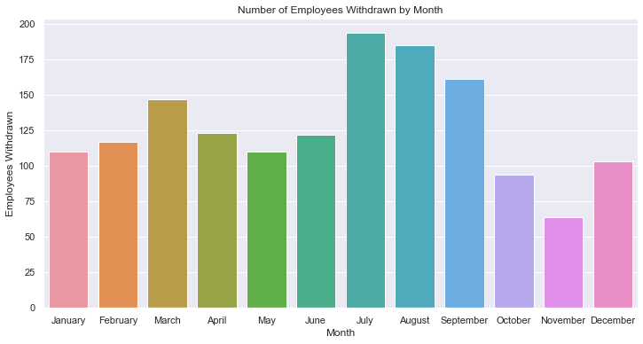

```python
#set up the figure
plt.figure(figsize=(12,6))
plt.setp(ax.get_xticklabels(), rotation=30, horizontalalignment='right')

#plot
sns.countplot(data=let_go,x='withdraw_month',order=month_order)

#labels and title
plt.ylabel('Employees Withdrawn')
plt.xlabel('Month')
plt.title('Number of Employees Withdrawn by Month')

#show
plt.show()

if record:
    plt.savefig('5.1_Number of Employees Withdrawn by Month.png')
```

## What were the ethnic orgins of the employees let go? And how does that compare to the percentage of that ethnic group in the city?

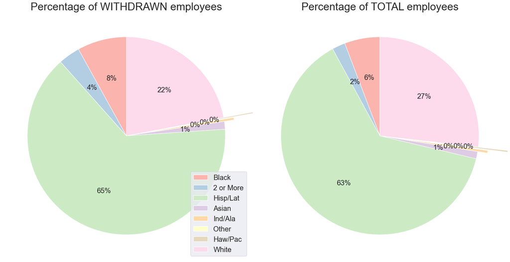

```python
#ax1,ax2 set up 2 two pies
fig, (ax1,ax2) = plt.subplots(1,2,figsize=(20,40)) #ax1,ax2 refer to your two pies

#set colors and explode
colors = sns.color_palette('Pastel1')
explode = [0, 0, 0, 0, 0.1, 0.2, 0.3, 0]

#--------------------------------------WITHDRAWN PIE #1-----------------------------
#set variables and title

labels = byEthnicity.index
sizes = byEthnicity['withdrawn']
ax1.set_title('Percentage of WITHDRAWN employees',
              fontsize='30')

#plot
ax1.pie(sizes,
        colors=colors,
        startangle=90,
        explode=explode,
        autopct='%.0f%%',
       textprops={'fontsize': 20})

ax1.legend(labels,loc='lower right',fontsize='20')

#---------------------------------------TOTAL PIE #2----------------------------------
#set variables and title
labels = byEthnicity.index
sizes = byEthnicity['total']
ax2.set_title('Percentage of TOTAL employees',
             fontsize = '30')

#plot
ax2.pie(sizes,
        colors=colors,
        startangle=90,
        explode=explode,
       autopct='%.0f%%',
       textprops={'fontsize': 20})

# make look nice
fig.autofmt_xdate()
plt.tight_layout()

if record:
    plt.savefig('8.1_Total vs Withdrawn by ethntic orgin PIE.png')
```

### Now as a barchart

A disproportionately number of Hispanics and minority groups were fired or quit in 2021. Despite White people making up 27% of the work force, only 22% of the withdrawn employees were white

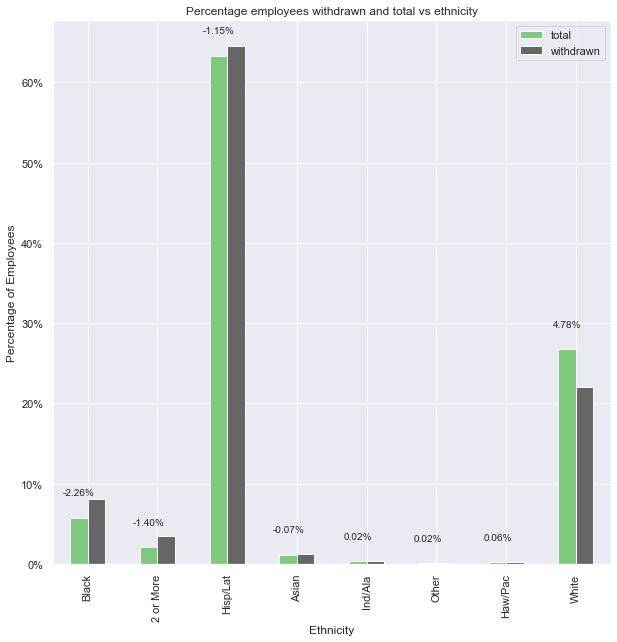

```python
#plot
ax = byEthnicity[['total','withdrawn']].plot(figsize=(10,10),kind='bar',cmap='Accent')

#make y axis in percents
ax.yaxis.set_major_formatter(mpl.ticker.StrMethodFormatter('{x:,.0f}%'))

#set labels and titles
plt.xlabel('Ethnicity')
plt.ylabel('Percentage of Employees')
plt.title('Percentage employees withdrawn and total vs ethnicity')

#show difference between total and withdrawn employees
annotations = ax.bar_label(ax.containers[0],labels=['%.2f%%' % n for n in difference], padding=20)

#show
plt.show()

if record:
    plt.savefig('8.2_Percentage employees withdrawn and total vs ethnicity'.png)
```

# LIBRARY

## Who are the top 20 earners in the library Business Area

Again, they are either in leadership positions, or an assistant to the director

```python
top_20_library
```

|  | full_name | job_title | annual_salary |
| --- | --- | --- | --- |
| 68 | RAMIRO S. SALAZAR | LIBRARY DIRECTOR | $188,549 |
| 636 | KATHLEEN ELAINE DONELLAN | ASSISTANT LIBRARY DIRECTOR | $138,084 |
| 618 | DALE MCNEILL | ASST LIBRARY DIRECTOR | $137,397 |
| 3323 | RICH WALKER | PROJECT CONTROL MANAGER | $106,248 |
| 3511 | RAYMOND FRAGA | SPECIAL PROJECTS MANAGER | $100,756 |
| 4018 | CHERYL LYNN SHEEHAN | PUBLIC SERVICES ADMINISTRATOR | $94,044 |
| 4298 | GABRIELLA RAUSCHUBER | DEPARTMENT FISCAL ADMINISTRATOR | $91,571 |
| 4294 | JENNIFER JOAN VELASQUEZ | LIBRARY SERVICES MANAGER | $91,099 |
| 4771 | KATHRYN W STURTZ | LIBRARY SERVICES MANAGER | $91,099 |
| 4333 | JESSICA ELIZABETH ZURITA | EXECUTIVE ASSISTANT | $89,739 |
| 4335 | HALEY K HOLMES | PUBLIC SERVICES ADMINISTRATOR | $89,440 |
| 4666 | ROBERTA A SPARKS | SPECIAL PROJECTS MANAGER | $85,845 |
| 4655 | RON SUSZEK | LIBRARY SERVICES ADMINISTRATOR | $85,243 |
| 4610 | ELMA NIETO-RODRIGUEZ | PUBLIC SERVICES ADMINISTRATOR | $82,465 |
| 4645 | CRESENCIA S HUFF | LIBRARY SERVICES MANAGER | $82,185 |
| 10686 | DAVID L COOKSEY | SENIOR MANAGEMENT ANALYST | $78,128 |
| 4896 | TROY CORWIN HOYLES | LIBRARY SERVICES MANAGER | $77,250 |
| 4901 | ADAM MATTHEW SPANA | LIBRARY SERVICES MANAGER | $77,250 |
| 4922 | MARK LEWIS JENKINS | FACILITIES MANAGER | $75,945 |
| 5029 | MORGAN YOSHIMURA | LIBRARY SERVICES MANAGER | $75,000 |

## Reference Department

```python
#There are 23 employees
print(f'I had {len(reference_employees)} coworkers at the library')
```

```
I had 24 coworkers at the library
```

```python
#16 of them were found in the database
coworkers = library_comp['first_last'].isin(values=reference_employees).value_counts()[1]
print(f'{coworkers} of them worked for the city in 2021')
```

```
17 of them worked for the city in 2021
```

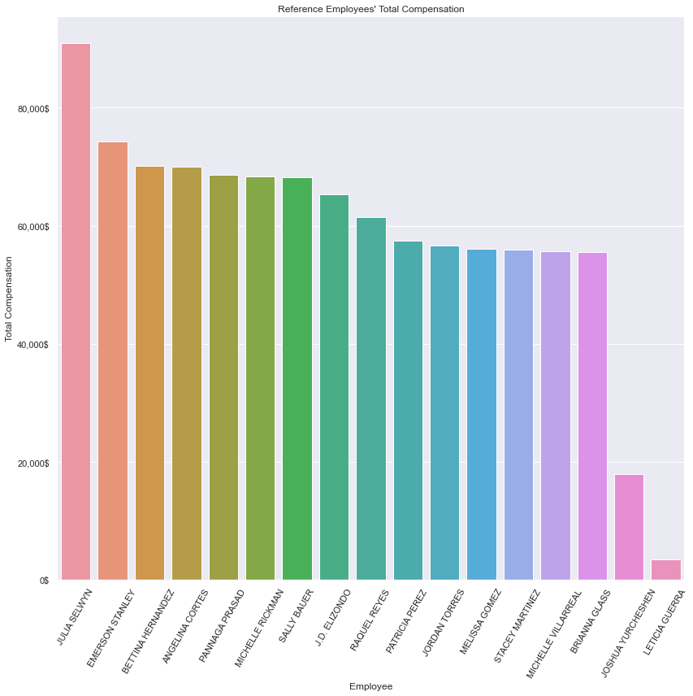

```python
#set up the figure
plt.figure(figsize=(12,12))

#plot
ax1 = sns.barplot(data = reference_dep[['first_last','total_compensation']],x='first_last',y='total_compensation')

#set labels and title
plt.xlabel('Employee')
plt.ylabel('Total Compensation')
plt.title("Reference Employees' Total Compensation")

# format numbers with $ and thousands comas
ax1.yaxis.set_major_formatter(mpl.ticker.StrMethodFormatter('{x:,.0f}$'))


#rotate ticks 60 degrees
labels = reference_dep.first_last.values
ax1.set_xticklabels(labels,rotation=60)

#make look nice
plt.tight_layout()

if record:
    plt.savefig('9.1_Reference Employees Total Compensation.png')
```

##### Take aways

```python
#Why did Leticia get paid so little?

#it's not her hire date she was hired in july? I'll ask her.
leti_start = str(library_comp[(library_comp['first_last']=='LETICIA GUERRA')]['hire_date']).split('\n')[0].split()[1]

print(f"Leticia didn't start working for the city until {leti_start} which would explain her low compensation")
```

```
Leticia didn't start working for the city until 2021-07-10 which would explain her low compensation
```

Julia was compensated much more than Emerson despite being a lower job title.

### How does this graph compare to year's worked?

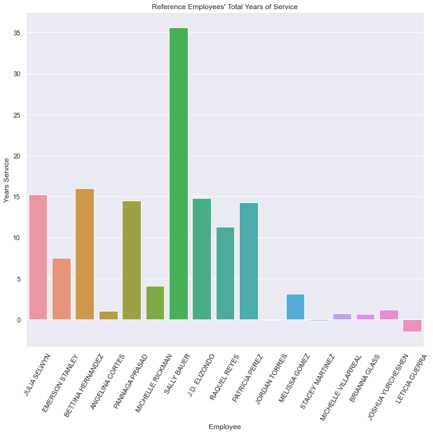

```python
#set up the figure
plt.figure(figsize=(10,10))

#plot
ax1 = sns.barplot(data = reference_dep,x='first_last',y='years_service')

#set labels and title
plt.xlabel('Employee')
plt.ylabel('Years Service')
plt.title("Reference Employees' Total Years of Service")

#rotate ticks 60 degrees
labels = reference_dep.first_last.values
ax1.set_xticklabels(labels,rotation=60)

#make look nice
plt.tight_layout()

if record:
    plt.savefig('9.2_Reference Employees Total Years of Service.png')
```

##### Take aways

Sally has worked at the library twice as long as anyone else on the team but only places in the middle when comparing incomes

Julia has also worked for the city twice as long as Emerson. That would explain the pay gap

### Let's see those two graphs side by side

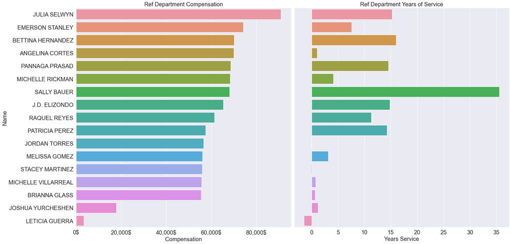

```python
#let's plot these side by side

#set up figure
plt.figure(figsize=(25,12))

#-----------------------------------set up left chart -------------------------------------------------------------------
ax1 = plt.subplot(1,2,1)


#plot

sns.barplot(data=reference_dep,
            y='first_last',
            x='total_compensation',
           )

#set up labels and title
plt.xlabel('Compensation',fontsize=20)
plt.ylabel('Name',fontsize=20)
plt.title('Ref Department Compensation',fontsize=20)
plt.yticks(fontsize=20)
plt.xticks(fontsize=20)

# format numbers with $ and thousands comas
ax1.xaxis.set_major_formatter(mpl.ticker.StrMethodFormatter('{x:,.0f}$'))

#-----------------------------------set up Right chart -------------------------------------------------------------------
ax2 = plt.subplot(1,2,2)

#plot
sns.barplot(data=reference_dep,
            y='first_last',
            x='years_service',
          )

#set up labels and title
plt.xlabel('Years Service',fontsize=20)

#remove names from Right table bc they match up
plt.yticks([])
plt.xticks(fontsize=20)

#remove y label
plt.ylabel('')
plt.title('Ref Department Years of Service',fontsize=20)


#make look nice
plt.tight_layout()
plt.subplots_adjust(hspace = 0.5)

#show
plt.show()
if record:
    plt.savefig('9.3_l1YearsVsSal.png')
```

# Poor Sally

## Let's look at each kind of librarian starting with librarian 1s

Here are some average L1 values

```python
l1s[['base_pay', 'leave_payout', 'other_pay', 'overtime', 'gross_earnings',
       'total_compensation', 'annual_salary', 'additional_benefits']].mean().apply(lambda x:str("{0:,.0f}$".format(x)))
```

```
base_pay               41,709$
leave_payout              824$
other_pay                 516$
overtime                    0$
gross_earnings         43,049$
total_compensation     59,594$
annual_salary          45,506$
additional_benefits    16,545$
dtype: object
```

### We'll compare distance from average salary and years worked

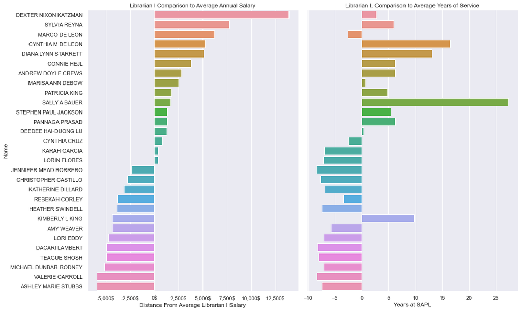

```python
#let's plot the l1s avg

#set up figure
plt.figure(figsize=(15,9))

#-----------------------------------set up left, compensation chart -------------------------------------------------------------------
ax1 = plt.subplot(1,2,1)


#plot

sns.barplot(data=l1s,
            y=l1s['full_name'],
            x=l1s['dif_mean_sal'],
          #  hue='gender'
           )

#set up labels and title
plt.xlabel('Distance From Average Librarian I Salary')
plt.ylabel('Name')
plt.title('Librarian I Comparison to Average Annual Salary')

# format numbers with $ and thousands comas
ax1.xaxis.set_major_formatter(mpl.ticker.StrMethodFormatter('{x:,.0f}$'))


#-----------------------------------set up Right, years service chart -------------------------------------------------------------------
ax2 = plt.subplot(1,2,2)

#plot
sns.barplot(data=l1s,
            y=l1s['full_name'],
            x=l1s['dif_from_years'],
        #    hue='gender'
          )

#set up labels and title
plt.xlabel('Years at SAPL')

#remove names from Right table bc they match up
plt.yticks([])

#remove y label
plt.ylabel('')
plt.title('Librarian I, Comparison to Average Years of Service')


#make look nice
plt.tight_layout()
plt.subplots_adjust(hspace = 0.5)

#show
plt.show()
if record:
    plt.savefig('9.3_l1YearsVsSal.png')
```

##### Take aways

Sally has worked $ten$ years $longer$ than any librarian 1 and barley makes more than the average

Marco de Leon is the the $3rd$ highest compensated librarian 1 despite working $less$ than the average number of years

Kimberly L King has worked at the library for $15$ $years$ $more$ than the people around her

## Librarian IIs

Here are some average L2 values

```python
l2s = library_comp[library_comp['job_title']=='LIBRARIAN II']
l2s = pd.DataFrame(l2s).set_index('full_name')
l2s[['base_pay', 'leave_payout', 'other_pay', 'overtime', 'gross_earnings',
       'total_compensation', 'annual_salary', 'additional_benefits']].mean().apply(lambda x:str("{0:,.0f}$".format(x)))
```

```
base_pay               49,713$
leave_payout            1,224$
other_pay                 514$
overtime                    0$
gross_earnings         51,452$
total_compensation     70,578$
annual_salary          52,140$
additional_benefits    19,126$
dtype: object
```

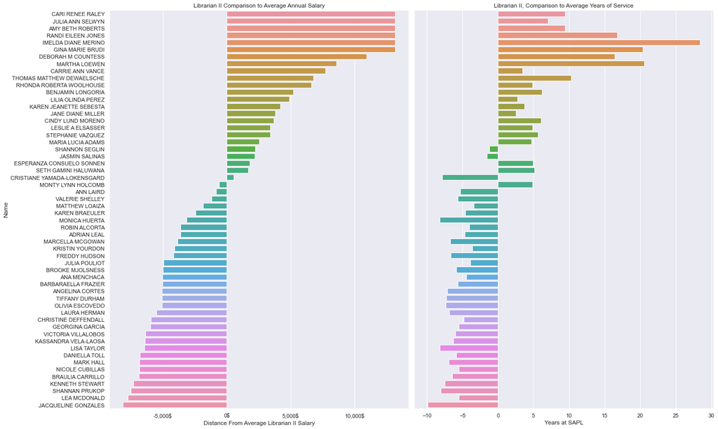

```python
#let's plot the l2s avg

#set up figure
plt.figure(figsize=(20,12))

#-----------------------------------set up left, compensation chart -------------------------------------------------------------------
ax1 = plt.subplot(1,2,1)


#plot

sns.barplot(data=l2s,
            y=l2s['full_name'],
            x=l2s['dif_mean_sal'],
          #  hue='gender'
           )

#set up labels and title
plt.xlabel('Distance From Average Librarian II Salary')
plt.ylabel('Name')
plt.title('Librarian II Comparison to Average Annual Salary')

# format numbers with $ and thousands comas
ax1.xaxis.set_major_formatter(mpl.ticker.StrMethodFormatter('{x:,.0f}$'))


#-----------------------------------set up Right, years service chart -------------------------------------------------------------------
ax2 = plt.subplot(1,2,2)

#plot
sns.barplot(data=l2s,
            y=l2s['full_name'],
            x=l2s['dif_from_years'],
        #    hue='gender'
          )

#set up labels and title
plt.xlabel('Years at SAPL')

#remove names from Right table bc they match up
plt.yticks([])

#remove y label
plt.ylabel('')
plt.title('Librarian II, Comparison to Average Years of Service')


#make look nice
plt.tight_layout()
plt.subplots_adjust(hspace = 0.5)

#show
plt.show()
if record:
    plt.savefig('9.3_l2YearsVsSal.png')
```

##### Take aways

The top six earners are all tied in compensation. I wonder if that is becuase there is a salary cap for this position?

### What about l3s?

```python
l3s = library_comp[library_comp['job_title']=='LIBRARIAN III']
l3s = pd.DataFrame(l3s).set_index('full_name')
l3s[['base_pay', 'leave_payout', 'other_pay', 'overtime', 'gross_earnings',
       'total_compensation', 'annual_salary', 'additional_benefits']].mean().apply(lambda x:str("{0:,.0f}$".format(x)))
```

```
base_pay               57,855$
leave_payout            1,938$
other_pay                 771$
overtime                    0$
gross_earnings         60,564$
total_compensation     81,742$
annual_salary          60,741$
additional_benefits    21,178$
dtype: object
```

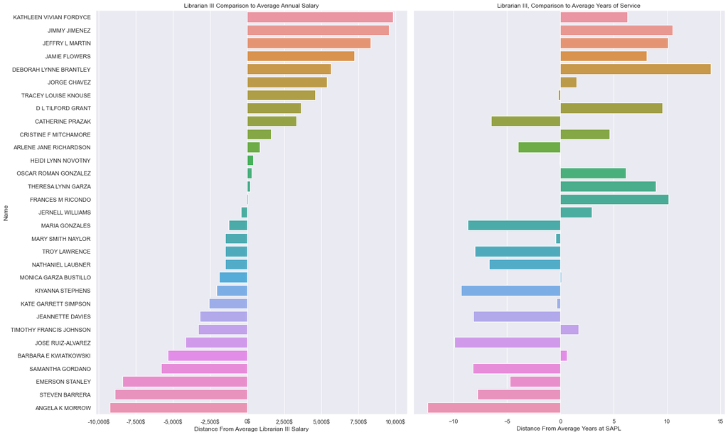

```python
#let's plot the l3s avg

#set up figure
plt.figure(figsize=(20,12))

#-----------------------------------set up left, compensation chart -------------------------------------------------------------------
ax1 = plt.subplot(1,2,1)


#plot

sns.barplot(data=l3s,
            y=l3s['full_name'],
            x=l3s['dif_mean_sal'],
          #  hue='gender'
           )

#set up labels and title
plt.xlabel('Distance From Average Librarian III Salary')
plt.ylabel('Name')
plt.title('Librarian III Comparison to Average Annual Salary')

# format numbers with $ and thousands comas
ax1.xaxis.set_major_formatter(mpl.ticker.StrMethodFormatter('{x:,.0f}$'))


#-----------------------------------set up Right, years service chart -------------------------------------------------------------------
ax2 = plt.subplot(1,2,2)

#plot
sns.barplot(data=l3s,
            y=l3s['full_name'],
            x=l3s['dif_from_years'],
        #    hue='gender'
          )

#set up labels and title
plt.xlabel('Distance From Average Years at SAPL')

#remove names from Right table bc they match up
plt.yticks([])

#remove y label
plt.ylabel('')
plt.title('Librarian III, Comparison to Average Years of Service')


#make look nice
plt.tight_layout()
plt.subplots_adjust(hspace = 0.5)

#show
plt.show()
if record:
    plt.savefig('9.3_l2YearsVsSal.png')
```

##### Take aways

This is all over the place

## Librarians by gender

```python
print(f'There are {female_count} female librarians and {male_count} male librarians that work for the city')
```

```
There are 91 female librarians and 25 male librarians that work for the city
```

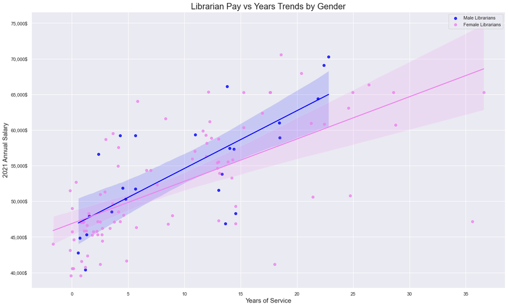

```python
#set up figure
plt.figure(figsize=(20,12))

#plot males
sns.regplot(data=male_libarians,
            x='years_service',
            y='annual_salary',
            label='Male Librarians',color='blue'
            )


#plot females
ax= sns.regplot(data=female_libarians,
            x='years_service',
            y='annual_salary',
            label='Female Librarians',color='violet'
            )


#titles and labes
plt.title('Librarian Pay vs Years Trends by Gender',fontsize=20)
plt.xlabel('Years of Service',fontsize=15)
plt.ylabel('2021 Annual Salary',fontsize=15)

#format y label to use comas and show $
ax.yaxis.set_major_formatter(mpl.ticker.StrMethodFormatter('{x:,.0f}$'))


#show plot and legend
plt.legend()
plt.show()
```

Male librarians tend to out earn females. In addition they seem to acumilate raises at a faster rate.

### Ethnicity in librarianship

```python
# Convert DataFrame object into its name as a string
librarian_ethnicities = [White,HispLat,TwoOrMore ,Black ,Asian]

for item in librarian_ethnicities:
    df_name = [name for name in globals() if globals()[name] is item][0]
    print(f'There are {len(item)} {df_name} librarians')
```

```
There are 66 White librarians
There are 40 HispLat librarians
There are 2 TwoOrMore librarians
There are 5 Black librarians
There are 3 Asian librarians
```

### Lets compare white and hispanic librarians

Unfortunately, there isn't quite enough data to look at the other groups for trends

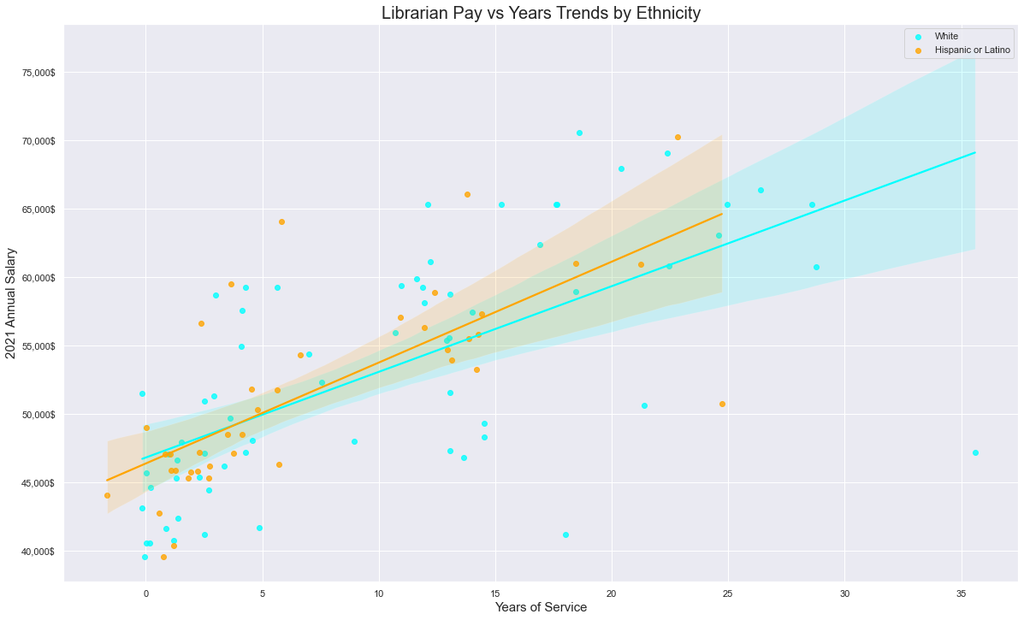

```python
plt.figure(figsize=(20,12))

#plot white
ax =sns.regplot(data=White,
            x='years_service',
            y='annual_salary',
            label='White',
            color='cyan'
            )

#plot hispanic
sns.regplot(data=HispLat,
            x='years_service',
            y='annual_salary',
            label='Hispanic or Latino',
            color='orange'
            )

#titles and labes
plt.title('Librarian Pay vs Years Trends by Ethnicity',fontsize=20)
plt.xlabel('Years of Service',fontsize=15)
plt.ylabel('2021 Annual Salary',fontsize=15)

#format y label to use comas and show $
ax.yaxis.set_major_formatter(mpl.ticker.StrMethodFormatter('{x:,.0f}$'))


#show plot and legend
plt.legend()
plt.show()
```

It seems that Hispanics tend to make more and get raises more quickly. However, the difference isn't as steep as it was in male vs female

## All library employees

```python
library_ethnicities = [White,HispLat,TwoOrMore ,Black ,Asian, Other]

for item in library_ethnicities:
    df_name = [name for name in globals() if globals()[name] is item][0]
    print(f'There are {len(item)} {df_name} library employees')
```

```
There are 178 White library employees
There are 305 HispLat library employees
There are 10 TwoOrMore library employees
There are 17 Black library employees
There are 8 Asian library employees
There are 2 item library employees
```

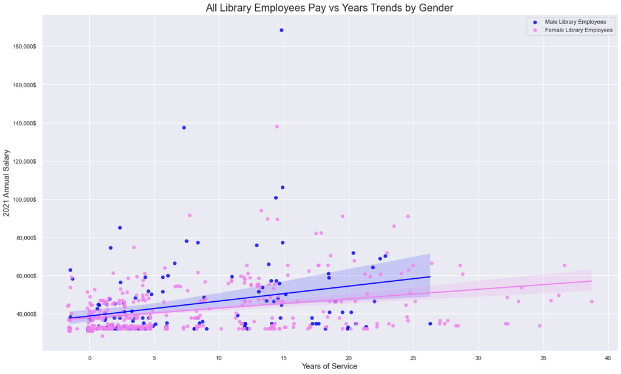

```python
#set up figure
plt.figure(figsize=(20,12))

#plot males
sns.regplot(data=males,
            x='years_service',
            y='annual_salary',
            label='Male Library Employees',color='blue'
            )


#plot females
ax= sns.regplot(data=females,
            x='years_service',
            y='annual_salary',
            label='Female Library Employees',color='violet'
            )


#titles and labes
plt.title('All Library Employees Pay vs Years Trends by Gender',fontsize=20)
plt.xlabel('Years of Service',fontsize=15)
plt.ylabel('2021 Annual Salary',fontsize=15)

#format y label to use comas and show $
ax.yaxis.set_major_formatter(mpl.ticker.StrMethodFormatter('{x:,.0f}$'))


#show plot and legend
plt.legend()
plt.show()
```

Again, males out earn females and get better raises

### Ethnicity: This time lets also plot black library employees

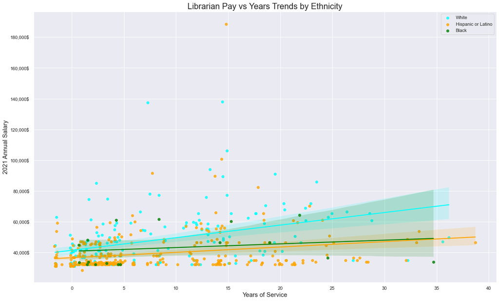

```python
plt.figure(figsize=(20,12))

#plot white
ax =sns.regplot(data=White,
            x='years_service',
            y='annual_salary',
            label='White',
            color='cyan'
            )

#plot hispanic
sns.regplot(data=HispLat,
            x='years_service',
            y='annual_salary',
            label='Hispanic or Latino',
            color='orange'
            )

#plot hispanic
sns.regplot(data=Black,
            x='years_service',
            y='annual_salary',
            label='Black',
            color='green'
           )

#titles and labes
plt.title('Librarian Pay vs Years Trends by Ethnicity',fontsize=20)
plt.xlabel('Years of Service',fontsize=15)
plt.ylabel('2021 Annual Salary',fontsize=15)

#format y label to use comas and show $
ax.yaxis.set_major_formatter(mpl.ticker.StrMethodFormatter('{x:,.0f}$'))


#show plot and legend
plt.legend()
plt.show()
```

##### Take aways:

I love that the director is at the very top. Making more than 40,000$ than the next employees (his assistants).

### Again, but only looking at full time library employees

```python
library_ethnicities = [White,HispLat,TwoOrMore ,Black ,Asian, Other]

for item in library_ethnicities:
    df_name = [name for name in globals() if globals()[name] is item][0]
    print(f'There are {len(item)} {df_name} library employees')
```

```
There are 139 White library employees
There are 198 HispLat library employees
There are 6 TwoOrMore library employees
There are 14 Black library employees
There are 7 Asian library employees
There are 1 item library employees
```

'item library' should say 'Other'

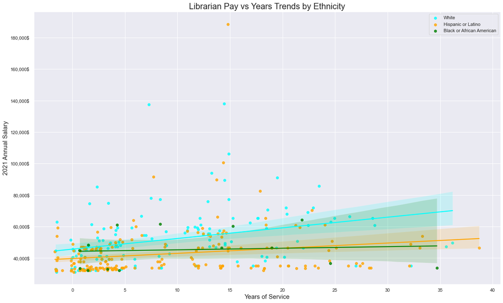

```python
plt.figure(figsize=(20,12))

#plot white
ax =sns.regplot(data=White,
            x='years_service',
            y='annual_salary',
            label='White',
            color='cyan'
            )

#plot hispanic
sns.regplot(data=HispLat,
            x='years_service',
            y='annual_salary',
            label='Hispanic or Latino',
            color='orange'
            )

#plot black
sns.regplot(data=Black,
            x='years_service',
            y='annual_salary',
            label='Black or African American',
            color='green'
           )

#titles and labes
plt.title('Librarian Pay vs Years Trends by Ethnicity',fontsize=20)
plt.xlabel('Years of Service',fontsize=15)
plt.ylabel('2021 Annual Salary',fontsize=15)

#format y label to use comas and show $
ax.yaxis.set_major_formatter(mpl.ticker.StrMethodFormatter('{x:,.0f}$'))


#show plot and legend
plt.legend()
plt.show()
```

Pretty much same result as before

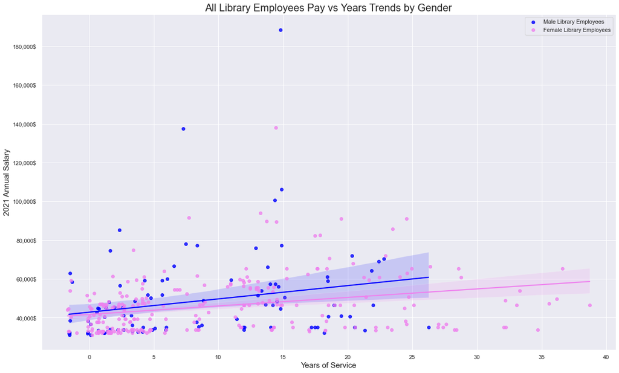

```python
#set up figure
plt.figure(figsize=(20,12))

#plot males
sns.regplot(data=males,
            x='years_service',
            y='annual_salary',
            label='Male Library Employees',color='blue'
            )


#plot females
ax= sns.regplot(data=females,
            x='years_service',
            y='annual_salary',
            label='Female Library Employees',color='violet'
            )


#titles and labes
plt.title('All Library Employees Pay vs Years Trends by Gender',fontsize=20)
plt.xlabel('Years of Service',fontsize=15)
plt.ylabel('2021 Annual Salary',fontsize=15)

#format y label to use comas and show $
ax.yaxis.set_major_formatter(mpl.ticker.StrMethodFormatter('{x:,.0f}$'))


#show plot and legend
plt.legend()
plt.show()
```

Again, pretty much the same result

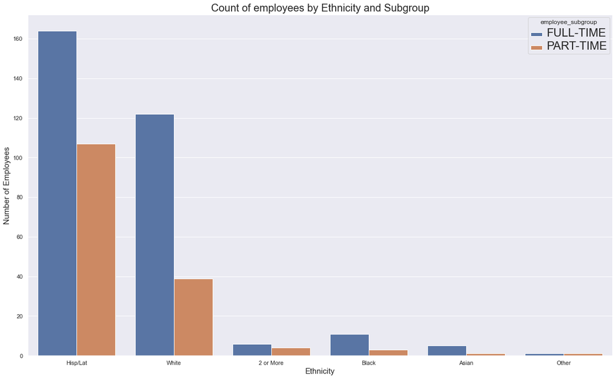

```python
plt.figure(figsize=(20,12))

#create a barchart hue will be the employee subgroup
#that counts the number of employees by ethnicity
ax =sns.countplot(comp_library['ethnicity_tags'],hue=comp_library['employee_subgroup'],)
plt.setp(ax.get_legend().get_texts(), fontsize='22')

#titles and labes
plt.title('Count of employees by Ethnicity and Subgroup',fontsize=20)
plt.xlabel('Ethnicity',fontsize=15)
plt.ylabel('Number of Employees',fontsize=15)

#show plot and legend

plt.show()
```

There are almost 3x as many Hispanic part timers ans white part timers.

## Is there any correlation between annual salary and gender?

City wide:

```python
as_vs_g
```

|  | annual_salary | gender |
| --- | --- | --- |
| annual_salary | 1.000000 | 0.213651 |
| gender | 0.213651 | 1.000000 |

There is a weak correlation between gender and annual salary (favoring males)

Library:

```python
lib_as_vs_g
```

|  | annual_salary | gender |
| --- | --- | --- |
| annual_salary | 1.000000 | 0.072547 |
| gender | 0.072547 | 1.000000 |

That correlation is much weaker when looking only at the library

### Is there any correlation between years worked and total compensation?

City wide: Yes. And this makes sense.

```python
ys_vs_tc
```

|  | total_compensation | years_service |
| --- | --- | --- |
| total_compensation | 1.000000 | 0.513635 |
| years_service | 0.513635 | 1.000000 |

Library: Yes. Although, it is slightly weaker.

```python
lib_ys_vs_tc
```

|  | total_compensation | years_service |
| --- | --- | --- |
| total_compensation | 1.000000 | 0.396394 |
| years_service | 0.396394 | 1.000000 |

# Conclusion

My coworker Sally is being slighted by the city

Men out earn women and get raises more quickly than women.

COSA spends a huge percentage of its bugent of fire and police